# Political (data) Science - Assignment 3

Tony Hui

```r
cat("
<style>
h2 {
  font-size: 24px;
  color:#045a8d;
  text-align:center;
}

h3 {
  font-size: 10px;
  color:#2b8cbe;
  text-align:center;
}

h4 {
  font-size: 14px;
  color:#2b8cbe;
}
</style>
")
```

## Part I: Hitting Slumps and Proportional Data

```
It is baseball time and the Toronto Blue Jays are in the playoffs. Josh Donaldson is a player for the Blue Jays and the 2015 Most Valuable Player of the Major League Baseball league. Over his 6-year career, Donaldson has been a .278 batter, meaning that his probability of getting a hit on any given …

Earlier in September as the Blue Jays were pushing toward the playoffs, Donaldson went a stretch of 21 at bats (attempts) where he only had 3 hits (successes), that is, just a 0.143 batting average. This led a TV analyst to announce that Donaldson was in a severe hitting slump at the absolute worst …
```

### 1.

#### Assuming Donaldson has a 27.8% chance of getting a hit each time he comes up to bat, find the mean and standard error of the sampling distribution of the proportion of hits he will get in 21 at bats.

Standard error = sqrt(pq/n)

```r
(mean = 21*0.278)
```

```
## [1] 5.838
```

```r
(sd = sqrt(0.278*(1-0.278)/21))
```

```
## [1] 0.09776454
```

### 2.

#### How many standard errors from the mean is this result of getting 3 hits in 21 at bats?

```r
(3-mean)/sd
```

```
## [1] -29.02893
```

## Part II: Conditional Probabilities with R

```
Assume a particular test for a deadly disease was inaccurate in detecting the disease 5% of the time (false negative rate) and the test has a false positive rate of only 1%. If 0.5% of the population being tested had the disease [Hint: you may want to draw a probability tree to visualize this better…
```

[figure not shown]

### 1.

#### What proportion of the population would be diagnosed as having the disease?

P(Test positive) = P(disease ∩ Test positive) + P(no disease ∩ Test Positive)

*∩ = and. For example, P(A∩B) = probability that A and B happening at same time*

```r
(p_positive = 0.005*0.95+0.995*0.01)
```

```
## [1] 0.0147
```

### 2.

#### Of the people diagnosed with having the disease, what proportion would actually have it?

P(disease | test positive) = P(disease) * P(test positive | disease) / P(test positive)

*| = given. For example, P(A|B) = probability that A happens given B happens*

```r
0.005*0.95/p_positive
```

```
## [1] 0.3231293
```

### 3.

#### Of the people diagnosed as not having the disease, what proportion would actually have the disease?

P(disease | test negative) = P(disease) * P(test negative | disease) / P(test negative)

```r
p_negative = 0.005*0.05+0.995*0.99
0.005*0.05/p_negative
```

```
## [1] 0.0002537298
```

## Part III: Binomial Distribution and Cumulative Probabilities

```
I have long been a fan of the Cleveland Browns football team… yes, I know, it is a rather sad perpetual state of existence. This past Sunday the Cleveland Browns lost to the New England Patriots to fall to 0-5 (0 wins and 5 losses).

Let’s assume that each time the Browns play a game this season, their probability of winning is 0.188 (based on their record last year of 3-13, which works out to a winning percentage of 18.8%). That is, assume that the probability of winning is always 0.188 and that each game is independent of the …

Using the binomial distribution, calculate the following probabilities:
```

### 1.

#### That my beloved Browns would start the season 0 – 5.

```r
dbinom(x = 0, size = 5, prob = 0.188)
```

```
## [1] 0.3530044
```

### 2.

#### That they will win next week and ease my pain and suffering at least a bit.

```r
dbinom(x = 1, size = 1, prob = 0.188)
```

```
## [1] 0.188
```

### 3.

#### That over the entire season of 16 games they would have matched their win total from last year and reached exactly 3 wins.

```r
dbinom(x = 3, size = 16, prob = 0.188)
```

```
## [1] 0.2482504
```

### 4.

#### That they would win at least 3 games.

```r
sum(dbinom(x = 3:16, size = 16, prob = 0.188))
```

```
## [1] 0.6021998
```

### 5.

#### That they will win at least 3 games now, given that they have started 0 – 5.

```r
sum(dbinom(x = 3:(16-5), size = 16-5, prob = 0.188))
```

```
## [1] 0.3427969
```

## Part IV: Sample Distribution and Cumulative Probabilities

```
This exercise will use 2 different recent national polls on the U.S. Presidential Election. In the questions that follow you want to use the “Two Party Vote Share of Decided Voters”.
```

| Company | Dates | Sample Size | 2 Party Vote Share of Decided Voters |  |
| --- | --- | --- | --- | --- |
|  |  |  | Clinton | Trump |
| Wall St. Jrnl | 10/08 – 10/9 | 447 | 56.8 | 43.2 |
| NBC News | 10/3 – 10/9 | 23329 | 52.9 | 47.1 |

### 1.

#### For each poll, how confident are we that the sample values reported represent the true probability that Americans favour Clinton? (That is, calculate what is generally reported as the margin of error of a poll).

Calculate standard error: `sqrt(pq/n)`

```r
(poll1_se = sqrt(0.568*0.432/447))
```

```
## [1] 0.02342946
```

```r
(poll2_se = sqrt(0.529*0.471/23329))
```

```
## [1] 0.003268062
```

### 2.

#### Assuming a normal distribution, for each poll what is the probability that Trump actually has support from at least 50.1% of the electorate?

```r
pnorm(0.501, 0.432, poll1_se, lower.tail = FALSE)
```

```
## [1] 0.00161472
```

```r
pnorm(0.501, 0.471, poll2_se, lower.tail = FALSE)
```

```
## [1] 2.160394e-20
```

### 3.

#### Assuming a normal distribution, what is the probability that Clinton actually has support from at least 50.1% but no more than 53% of the electorate?

P(clinton > 0.501)*P(clinton < 0.53)

```r
pnorm(0.501, 0.568, poll1_se, lower.tail = FALSE)*pnorm(0.53, 0.568, poll1_se, lower.tail = TRUE)
```

```
## [1] 0.05230234
```

```r
pnorm(0.501, 0.529, poll2_se, lower.tail = FALSE)*pnorm(0.53, 0.529, poll2_se, lower.tail = TRUE)
```

```
## [1] 0.6201946
```

### 4.

#### Looking at your results for B and C, explain how the sample size of the polls affects your findings and polling more generally.

More sample size = more certain

### 5.

#### For the above problems, I told you to use the “2 Party Vote Share of Decided Voters”, which excludes undecided voters as well as those who support some 3rd party. In doing this it has made the analysis a bit easier, but I have also made some assumptions that might bias my results. In particular, what have I assumed about “undecided voters”? Is this a legitimate assumption? Explain.

Assumed that they would vote randomly. This may not be legitimate cause they might all vote trump

## Part V: Review of Regression with a Twist

```
Note: See How To Guide on Removing Observations and Accessing Subsets of Data.
```

### 1.

#### Using ggplot2 create a scatterplot of the relationship between “gini” income inequality coefficient (x and independent variable) and “hobbes” (y and dependent variable) quality of life index.

```r
Countries=read.csv("http://www.sfu.ca/~sweldon/Countries.csv")
library(ggplot2)
```

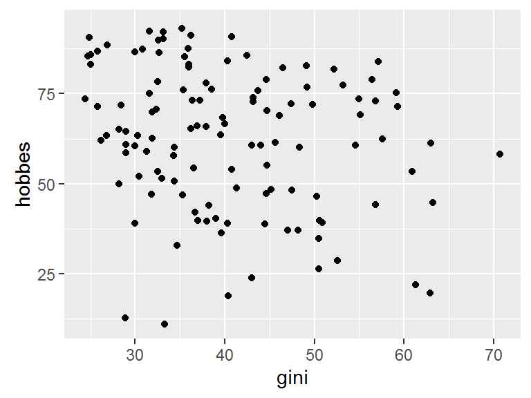

```r
ggplot(Countries, aes(gini, hobbes)) +
  geom_point()
```

### 2.

#### Create the same scatterplot as above, but plot free, partly free, and not free countries separately. Add the regression lines for each group separately.

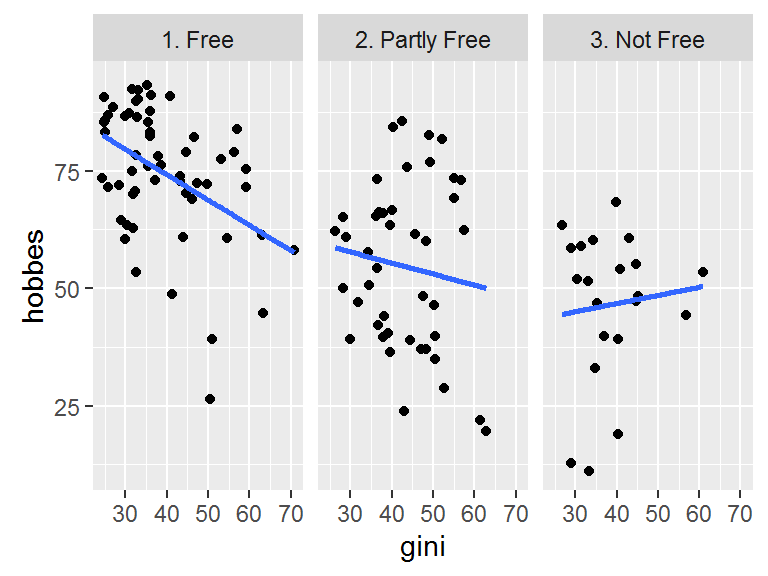

```r
ggplot(Countries, aes(gini, hobbes)) +
  geom_point() +
  geom_smooth(method ="lm", se=F) +
  facet_wrap(~fh)
```

### 3.

#### For each level of freedom separately, find the predicted hobbesian quality of life score that a country would have if they had a gini coefficient of 45.

```r
free_model <- subset(Countries, fh == "1. Free")
lm(hobbes ~ gini, free_model)
```

```
##
## Call:
## lm(formula = hobbes ~ gini, data = free_model)
##
## Coefficients:
## (Intercept)         gini
##     95.6478      -0.5368
```

```r
-0.5368*45+95.6478
```

```
## [1] 71.4918
```

```r
partlyfree_model <- subset(Countries, fh == "2. Partly Free")
lm(hobbes ~ gini, partlyfree_model)
```

```
##
## Call:
## lm(formula = hobbes ~ gini, data = partlyfree_model)
##
## Coefficients:
## (Intercept)         gini
##     64.7842      -0.2341
```

```r
-0.2341*45+64.7842
```

```
## [1] 54.2497
```

```r
notfree_model <- subset(Countries, fh == "3. Not Free")
lm(hobbes ~ gini, notfree_model)
```

```
##
## Call:
## lm(formula = hobbes ~ gini, data = notfree_model)
##
## Coefficients:
## (Intercept)         gini
##     39.8480       0.1734
```

```r
0.1734*45+39.8480
```

```
## [1] 47.651
```

### 4.

#### What do the results in 2 and 3 tell you about the relationship between income inequality and quality of life?

Not free countries have positive relationship, while free countries have negative relationship